# gilmore-csc-talk

October 28, 2016

**The future of big data in developmental science – Answering the big questions**

### **Rick O. Gilmore**

*Support*: NSF BCS-1147440, NSF BCS-1238599, NICHD U01-HD-076595

## Overview

- Where are we now?
- Challenges
- Some thoughts on the future

## Biq questions, big dreams

[figure not shown]

Shonkoff, J. P., & Phillips, D. A. (Eds.). (2000). From neurons to neighborhoods: The science of early childhood development. National Academies Press.

[figure not shown]

[figure not shown]

## So, how is developmental science doing?

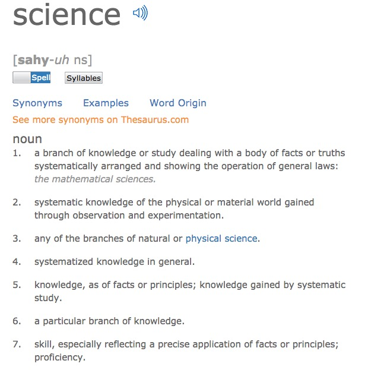

[figure not shown]

## Challenges with 'big data' developmental science

- Collect diverse types of data
- Must aggregate, link data across **space**, **time**, **individual identities**
- Data not spatially uniform
- Time series not uniformly sampled, different sampling intervals

[figure not shown]

## Challenges…

- Aggregating big data about individuals poses privacy risks

[figure not shown]

## Challenges…

- Most data collected are from WEIRD populations [(Henrich, Heine, and Norenzayan 2010)](http://doi.org/10.1017/S0140525X0999152X)
- Studies underpowered [(Maxwell 2004)](http://doi.org/10.1037/1082-989X.9.2.147)
- Findings hard to reproduce/replicate

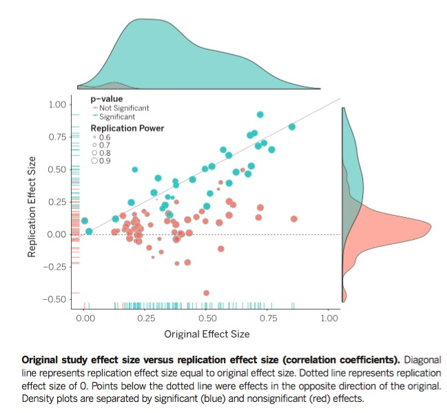

[(Collaboration 2015)](http://doi.org/10.1126/science.aac4716)

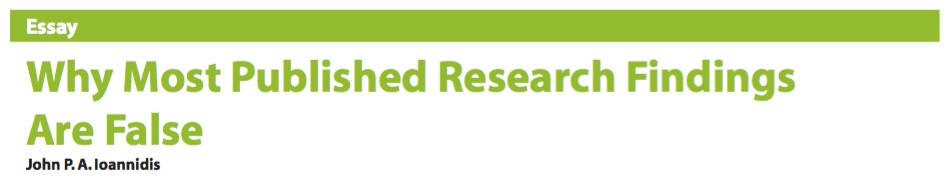

[(J. P. A. Ioannidis 2005)](http://dx.doi.org/10.1371/journal.pmed.0020124)

"We have empirically assessed the distribution of published effect sizes and estimated power by extracting more than 100,000 statistical records from about 10,000 cognitive neuroscience and psychology papers published during the past 5 years…**False report probability is likely to exceed 50% for the whole literature. In light of our findings the recently reported low replication success in psychology is realistic** and worse performance may be expected for cognitive neuroscience."

[(Szucs and Ioannidis 2016)](http://doi.org/10.1101/071530)

## Challenges to replicability

- Still collect data in non-electronic formats
- Even electronic formats not readily shareable
- Vital metadata (geo-, participant-level) often not collected
- "Reproducible" workflows not standard practice
- Results have limited robustness and generalizability
- Misunderstanding/agreement about what reproducibility means
- **Methods reproducibility** refers to the provision of enough detail about study procedures and data so the same procedures could, in theory or in actuality, be exactly repeated.
- **Results reproducibility** (previously described as replicability) refers to obtaining the same results from the conduct of an independent study whose procedures are as closely matched to the original experiment as possible.

[(Goodman, Fanelli, and Ioannidis 2016)](http://doi.org/10.1126/scitranslmed.aaf5027)

- **Robustness** refers to the stability of experimental conclusions to variations in either baseline assumptions or experimental procedures.
- **Generalizability** refers to the persistence of an effect in settings different from and outside of an experimental framework.

[(Goodman, Fanelli, and Ioannidis 2016)](http://doi.org/10.1126/scitranslmed.aaf5027)

## Do we have…

- Reproducible methods
- Reproducible results
- Robust fundings
- Generalizable findings

[figure not shown]

## The Year 4 A.D.

- A.D. = After [Databrary](http://databrary.org)

[interactive chart not shown]

Gilmore, R. O. (2016). From big data to deep insight in developmental science. *Wiley Interdisciplinary Reviews: Cognitive Science*, *7*(2), 112–126. https://doi.org/10.1002/wcs.1379

## Lessons learned

## Big data developmental studies have long histories

[figure not shown]

## But, big cohort studies have uncertain futures

- [National Children's Study (NCS)](https://www.nichd.nih.gov/research/NCS/Pages/default.aspx)
- [U.K. Life Study](http://www.nature.com/news/massive-uk-baby-study-cancelled-1.18650)

## But, big cohort studies have uncertain futures

- [National Children's Study (NCS)](https://www.nichd.nih.gov/research/NCS/Pages/default.aspx)
- [U.K. Life Study](http://www.nature.com/news/massive-uk-baby-study-cancelled-1.18650)

[interactive chart not shown]

## Data sharing is part of the solution, but

- We don't agree about who owns data
  - Participants
  - Us
  - Penn State
  - The taxpayer
- Minimal rewards for data sharing
- Post hoc sharing hard, time-consuming, expensive

[interactive chart not shown]

[figure not shown]

*"You can checkout any time you like, but you can never leave."*

## Building a culture of reuse, reanalysis, meta-analysis

- Why share if no one will reuse, build upon?
- Journals don't always encourage/support/mandate publication of data, detailed methods
  - Guidelines for [Transparency and Openness Promotion](https://cos.io/top/#list) from the Center for Open Science (COS)
- Building community consensus better than centralized mandates

## Datasets can be "magnets" for scholarship

[figure not shown]

## Centralizing shared data can enable discovery

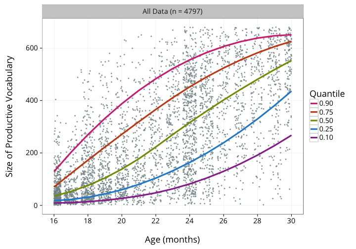

http://wordbank.stanford.edu/analyses?name=vocab_norms

[interactive chart not shown]

http://datausa.io

## Video essential

- Numeric, text-based measures miss/reduce complexity of behavior
- Video captures and preserves it
- Replications can fail due to methodological differences
- Methods sections can't possibly report essential details
- Video captures and preserves them

[Gilmore et al. talk](https://rawgit.com/databrary/presentations/master/nyu-data-science-reproducibility-16/be-bold.html)

## A robust and reproducible developmental science should…

- Video record all tasks, measures, and behaviors
- Share the recordings
- Share all questionnaires, tasks, displays
- Share statistical, computational, data workflows
- Prepare to share from the beginning
- Seek permission to share data

## Of course, it's hard(er) to collect and share sensitive or identifiable data

- But, not impossible

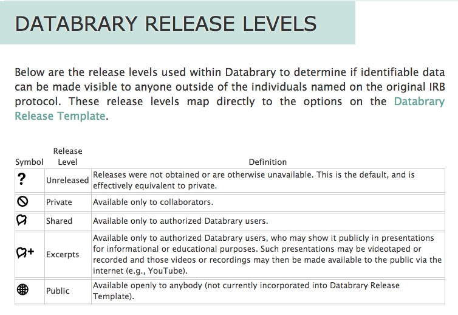

## When asked, most participants say yes

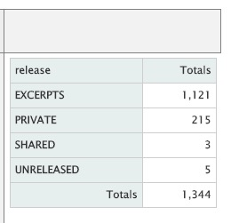

Tamis-LeMonda, C. (2013). http://doi.org/10.17910/B7CC74.

[figure not shown]

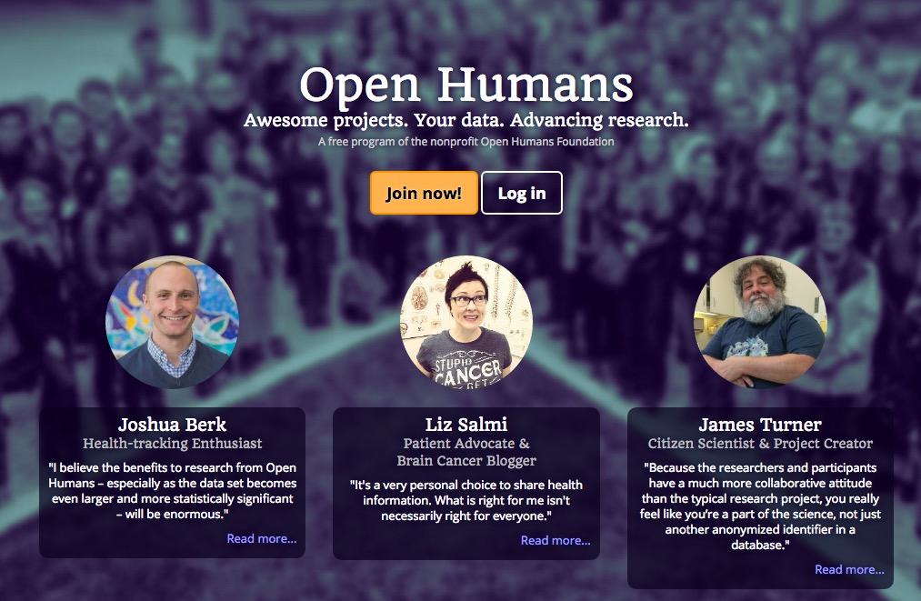

[figure not shown]

http://www.humanconnectome.org/

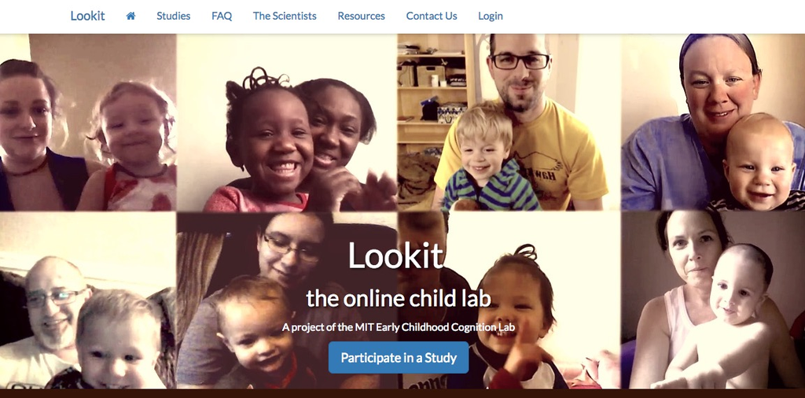

## People will *volunteer* information if they get something of value in return

[figure not shown]

## What is the value of participating in research?

- Contribute to public good
- Aid discovery
- Curiosity
- Help institution
- How can we better capitalize on the value the public places on our work?

## We need better tools, training

[figure not shown]

## Our measures need to be open, non-proprietary

- Are *your* preferred standardized/normed tasks open, non-proprietary?
- Can you share the questions/items with colleagues?
- Are the data underlying the norms openly available?
- [Wechlser](http://www.pearsonclinical.com/psychology/products/100000310/wechsler-intelligence-scale-for-children-fourth-edition-wisc-iv.html)
- [Autism Diagnostic Observation Schedule (ADOS)](http://www.wpspublish.com/store/p/2648/autism-diagnostic-observation-schedule-second-edition-ados-2)
- [MacArthur CDI](http://www.brookespublishing.com/resource-center/screening-and-assessment/cdi/)
- [Achenbach System of Empirically Based Assessment (ASEBA), e.g., CBCL, etc.](http://www.aseba.org/)
- [Wechlser](http://www.pearsonclinical.com/psychology/products/100000310/wechsler-intelligence-scale-for-children-fourth-edition-wisc-iv.html)
- [Autism Diagnostic Observation Schedule (ADOS)](http://www.wpspublish.com/store/p/2648/autism-diagnostic-observation-schedule-second-edition-ados-2)
- [MacArthur CDI](http://www.brookespublishing.com/resource-center/screening-and-assessment/cdi/)
- [Achenbach System of Empirically Based Assessment (ASEBA), e.g., CBCL, etc.](http://www.aseba.org/)
- Difficult to find, aggregate across studies, and reuse/reanalyze data drawn from most measures [(Gilmore 2016)](http://doi.org/10.1002/wcs.1379)

## We need to think bigger…

[figure not shown]

## Imagine a developmental "Databservatory"

[figure not shown]

## What would this micro/macro/telescope look like?

- Recruiting – larger, more diverse samples
- Data collection – more data types, allow linkage across levels
- Data curation/management – easy/automatic, standardized formats
- Data sharing – PI controls when, permission levels
- Data mining, visualization, linking
- Search, filter by participant characteristics, tasks/measures, geo/temporal factors
- Analysis in the "cloud"
- Automatic versioning, history

[figure not shown]

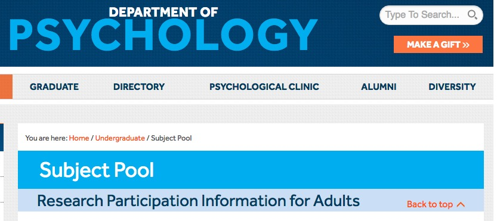

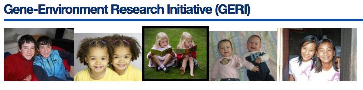

[figure not shown]

[figure not shown]

[figure not shown]

[figure not shown]

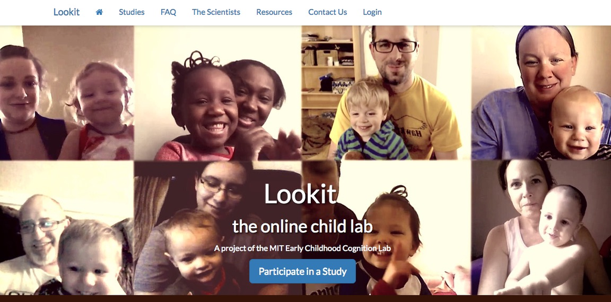

## The front end

- App/web service (MeeSearch.com)
- Linking researchers with participants (or parents)
- Participants own/control their data, determine level of sharing (like datawallet.io)
- Lab, computer/smart-phone based, survey tasks
- Data visualizations, dashboard
- 1,000+ psych pool/semester, 500K PSU alumni, 1M friends

## The middle

[figure not shown]

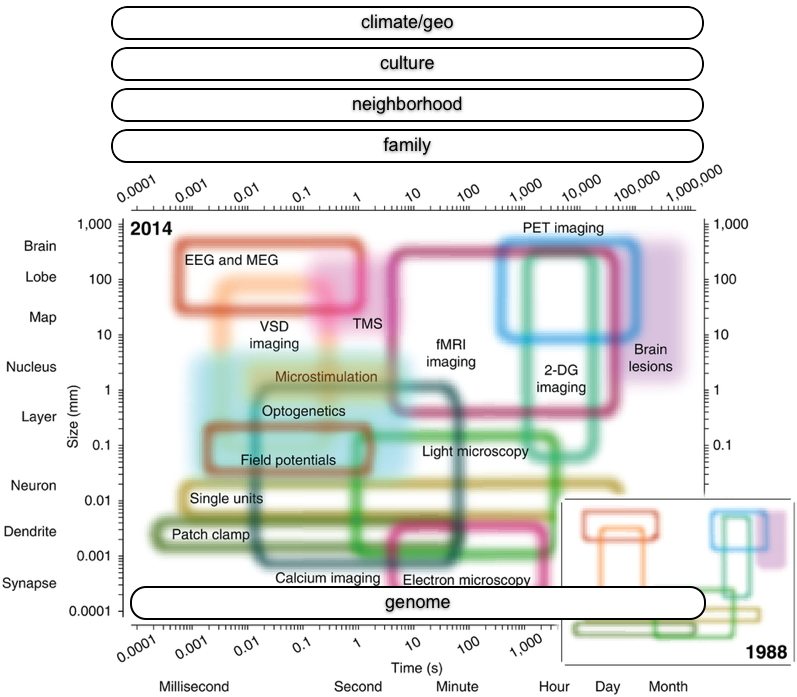

## Analytic/visualization/data publication engine

[interactive chart not shown]

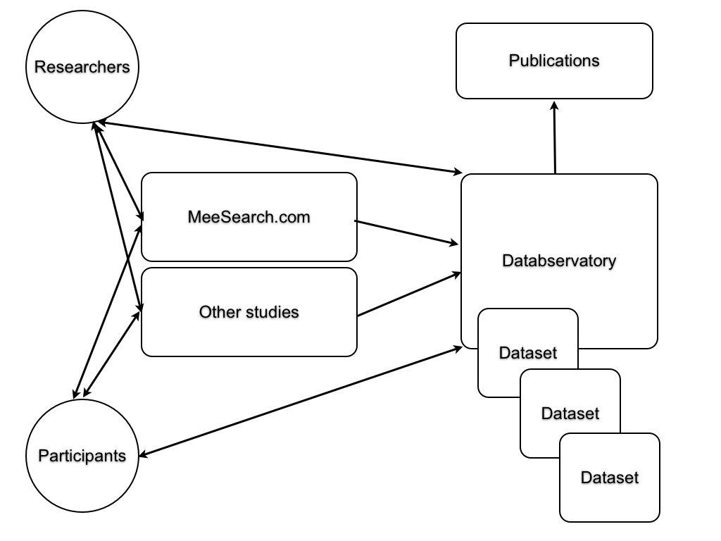

## What do you think?

- Shall we build it?
- After all…

[figure not shown]

## References

Gilmore, Rick O. 2016. “From Big Data to Deep Insight in Developmental Science.” *Wiley Interdisciplinary Reviews: Cognitive Science* 7 (2): 112–26. doi:10.1002/wcs.1379.

Goodman, Steven N., Daniele Fanelli, and John P. A. Ioannidis. 2016. “What Does Research Reproducibility Mean?” *Science Translational Medicine* 8 (341): 341ps12–341ps12. doi:10.1126/scitranslmed.aaf5027.

Henrich, Joseph, Steven J. Heine, and Ara Norenzayan. 2010. “The Weirdest People in the World?” *The Behavioral and Brain Sciences* 33 (2-3): 61–83; discussion 83–135. doi:10.1017/S0140525X0999152X.

Ioannidis, John P. A. 2005. “Why Most Published Research Findings Are False.” *PLoS Med* 2 (8): e124. doi:10.1371/journal.pmed.0020124.

Maxwell, Scott E. 2004. “The Persistence of Underpowered Studies in Psychological Research: Causes, Consequences, and Remedies.” *Psychological Methods* 9 (2): 147–63. doi:10.1037/1082-989X.9.2.147.

Szucs, Denes, and John PA Ioannidis. 2016. “Empirical Assessment of Published Effect Sizes and Power in the Recent Cognitive Neuroscience and Psychology Literature.” *BioRxiv*, August, 071530. doi:10.1101/071530.